# 데이콘 신용카드 사용자 연체 예측 AI 경진대회

20152410 배형준

# 1. EDA

https://www.dacon.io/competitions/official/235713/overview/description/

```r
library(dlookr) # diagnose
library(tidyverse) # dplyr, ggplot
library(GGally) # ggpairs
library(gridExtra) # grid.arrange
library(caret)
library(MLmetrics) # MultiLogLoss
library(xgboost) # xgboost
library(catboost) # catboost
library(doParallel) # registerDoParallel
```

```r
load('./environment.RData')
```

```r
# 병렬처리
cl = makeCluster(detectCores() - 1)
registerDoParallel(cl)
```

```r
# 데이터 불러오기
card_dataset = read_csv('./open/train.csv')
data = card_dataset # 사본 생성

test_dataset = read_csv('./open/test.csv')
```

```r
# 데이터 구조 확인
data %>% diagnose()
```

```
## # A tibble: 20 x 6
##    variables     types    missing_count missing_percent unique_count unique_rate
##    <chr>         <chr>            <int>           <dbl>        <int>       <dbl>
##  1 index         numeric              0             0          26457   1
##  2 gender        charact~             0             0              2   0.0000756
##  3 car           charact~             0             0              2   0.0000756
##  4 reality       charact~             0             0              2   0.0000756
##  5 child_num     numeric              0             0              9   0.000340
##  6 income_total  numeric              0             0            249   0.00941
##  7 income_type   charact~             0             0              5   0.000189
##  8 edu_type      charact~             0             0              5   0.000189
##  9 family_type   charact~             0             0              5   0.000189
## 10 house_type    charact~             0             0              6   0.000227
## 11 DAYS_BIRTH    numeric              0             0           6621   0.250
## 12 DAYS_EMPLOYED numeric              0             0           3470   0.131
## 13 FLAG_MOBIL    numeric              0             0              1   0.0000378
## 14 work_phone    numeric              0             0              2   0.0000756
## 15 phone         numeric              0             0              2   0.0000756
## 16 email         numeric              0             0              2   0.0000756
## 17 occyp_type    charact~          8171            30.9           19   0.000718
## 18 family_size   numeric              0             0             10   0.000378
## 19 begin_month   numeric              0             0             61   0.00231
## 20 credit        numeric              0             0              3   0.000113
```

occyp_type 변수에 결측값이 있는 것을 확인할 수 있습니다. 또한 factor 변수들이 character 타입로 설정되어 있어 변경할 필요가 있습니다. 추가로 numeric 변수의 분포를 확인하여 극단적일 경우 범주화 하려고 합니다.

## 데이터 전처리 함수 생성

```r
prepare_data = function(df, type = 'train'){

    ### 종속변수 형태 변환, type : train or test
    if (type == 'train'){
        df = df %>% mutate(credit = as.factor(credit))
    } else if (type == 'test'){
        df = df %>% mutate(credit = '999')
    }

    ### 질적 변수 전처리
    # gender : as.factor
    # car : as.factor
    # reality : as.factor
    # income_type : as.factor
    # edu_type : as.factor, ordered factor
    # family_type : as.factor
    # house_type : as.factor
    # FLAG_MOBIL : 모든 데이터가 1이기 때문에 삭제
    # work_phone : as.factor
    # phone : as.factor
    # email : as.factor
    # occyp_type : 1/3이 결측값이라 삭제
    df = df %>% mutate(gender = as.factor(gender),
                       car = as.factor(car),
                       reality = as.factor(reality),
                       income_type = as.factor(income_type),
                       edu_type = ordered(edu_type,
                                          levels = c('Academic degree',
                                                     'Higher education',
                                                     'Incomplete higher',
                                                     'Secondary / secondary special',
                                                     'Lower secondary')),
                       family_type = as.factor(family_type),
                       house_type = as.factor(house_type),
                       work_phone = as.factor(work_phone),
                       phone = as.factor(phone),
                       email = as.factor(email)) %>%
                select(-occyp_type, -FLAG_MOBIL)

    ### 양적 변수 전처리
    # child_num : 0, 1, 2, 3~4, 5, more_than_6으로 범주화하여 child_num_category 변수로 대체
    # DAYS_BIRTH : 절댓값을 365로 나눈 몫으로 age변수를 만들어 대체
    # DAYS_EMPLOYED : 양수인 값은 0으로, (음수인 값은 절댓값을 365로 나눈 몫) + 1으로 career_year 변수를 만들어 대체
    # family_size : child_num과 비슷한 경향을 가지지만 child_num은 범주화를 했기 때문에 연속형으로 남겨두겠음
    # parent_num : 가정 내 부모의 수, family_size - child_num으로 계산, 0 이하의 수(자식이 있지만 혼자 사는 경우)는 0으로 변경
    # begin_month : 절댓값 함수를 이용해 양수로 변경
    df = df %>% mutate(child_num_category = ordered(ifelse(child_num == 0, 'zero',
                                                   ifelse(child_num == 1, 'one',
                                                          ifelse(child_num == 2, 'two',
                                                                 ifelse(child_num %in% c(3, 4), 'three_or_four',
                                                                        ifelse(child_num == 5, 'five', 'more_than_6'))))),
                                                   levels = c('zero',
                                                              'one',
                                                              'two',
                                                              'three_or_four',
                                                              'five',
                                                              'more_than_6')),
                       age = abs(DAYS_BIRTH) %/% 365,
                       career_year = ifelse(DAYS_EMPLOYED >= 0, 0, (abs(DAYS_EMPLOYED) %/% 365) + 1),
                       parent_num = ifelse(family_size - child_num > 0, family_size - child_num, 0),
                       begin_month = abs(begin_month)) %>%
                select(-child_num, -DAYS_BIRTH, -DAYS_EMPLOYED)

    return(df)
}
```

```r
pre_data = prepare_data(data, type = 'train')
pre_test_data = prepare_data(test_dataset, type = 'test')

pre_data %>% diagnose()
```

```
## # A tibble: 19 x 6
##    variables       types  missing_count missing_percent unique_count unique_rate
##    <chr>           <chr>          <int>           <dbl>        <int>       <dbl>
##  1 index           numer~             0               0        26457   1
##  2 gender          factor             0               0            2   0.0000756
##  3 car             factor             0               0            2   0.0000756
##  4 reality         factor             0               0            2   0.0000756
##  5 income_total    numer~             0               0          249   0.00941
##  6 income_type     factor             0               0            5   0.000189
##  7 edu_type        order~             0               0            5   0.000189
##  8 family_type     factor             0               0            5   0.000189
##  9 house_type      factor             0               0            6   0.000227
## 10 work_phone      factor             0               0            2   0.0000756
## 11 phone           factor             0               0            2   0.0000756
## 12 email           factor             0               0            2   0.0000756
## 13 family_size     numer~             0               0           10   0.000378
## 14 begin_month     numer~             0               0           61   0.00231
## 15 credit          factor             0               0            3   0.000113
## 16 child_num_cate~ order~             0               0            6   0.000227
## 17 age             numer~             0               0           48   0.00181
## 18 career_year     numer~             0               0           45   0.00170
## 19 parent_num      numer~             0               0            3   0.000113
```

결측값이 많은 occyp_type 변수를 삭제하였습니다. character 변수를 factor화 했고, child_num 변수를 범주화하여 child_num_category 요약변수를 생성했습니다. edu_type, child_num_category는 순서척도라서 factor 대신 ordered 함수를 이용하였습니다.

전처리된 데이터로 통계 검정 및 시각화하여 종속변수와 독립변수간의 관계를 확인해보겠습니다.

## 시각화

```r
# 두 범주형 변수 간 카이제곱 검정
one_variable_chisq_test = function(df, var1, var2){

    ### 빈도표, 카이제곱검정 결과 출력
    result_table = df %>% select(var1, var2) %>% table()
    result_prop_table = result_table %>% apply(1, function(x){x / sum(x)}) %>% t()
    result_test = result_table %>% chisq.test()

    return(list(table = result_table,
                prop_table = result_prop_table,
                test = result_test))
}

# factor인 독립변수 vs 종속변수인 barplot 출력 함수 생성
barplot_factor_variable = function(df, var1, var2, text = TRUE){

    ### 두 범주형 변수의 빈도수 막대그래프 출력
    graph = df %>%
        select(var1, var2) %>%
        group_by_all() %>%
        summarise(count = n()) %>%
        mutate(prop = paste0(100*round(count / sum(count), 2), '%')) %>%
        ggplot(aes_string(x = var1, y = 'count', fill = var2)) +
        geom_bar(stat = 'identity', position = position_dodge()) +
        geom_text(aes(label = prop), position = position_dodge(0.9), vjust = -0.25, size = 3.5) +
        ggtitle(paste0('Barplot of ', var1, ' and ', var2)) +
        theme(plot.title = element_text(size = 15, hjust = 0.5))

    if (text == TRUE){
        graph = graph +
            geom_text(aes(label = count), position = position_dodge(0.9), vjust = 1.2, size = 4)
    }

    return(graph)
}
```

```r
pre_data %>% one_variable_chisq_test('income_type', 'credit') # 유의함
```

```
## $table
##                       credit
## income_type               0    1    2
##   Commercial associate  782 1344 4076
##   Pensioner             536 1084 2829
##   State servant         265  489 1400
##   Student                 0    3    4
##   Working              1639 3347 8659
##
## $prop_table
##                       credit
## income_type                    0         1         2
##   Commercial associate 0.1260884 0.2167043 0.6572074
##   Pensioner            0.1204765 0.2436503 0.6358732
##   State servant        0.1230269 0.2270195 0.6499536
##   Student              0.0000000 0.4285714 0.5714286
##   Working              0.1201173 0.2452913 0.6345914
##
## $test
##
##  Pearson's Chi-squared test
##
## data:  .
## X-squared = 23.675, df = 8, p-value = 0.002598
```

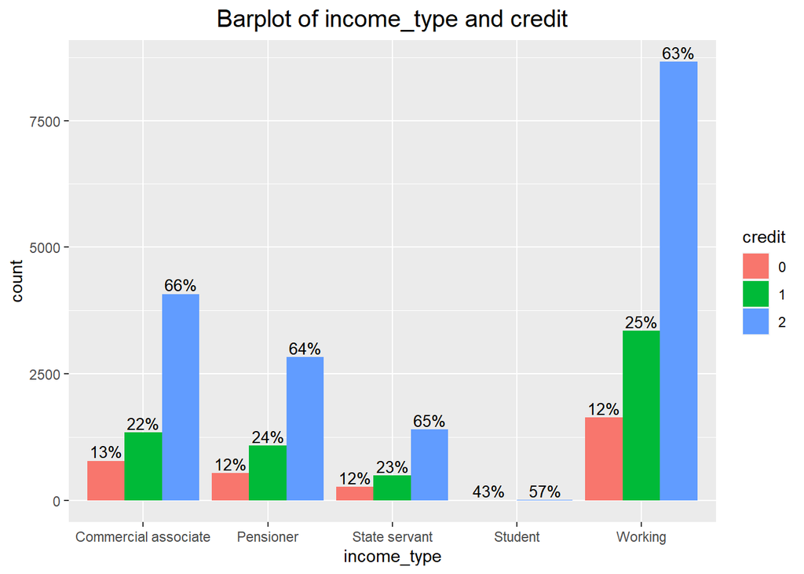

```r
pre_data %>% barplot_factor_variable('income_type', 'credit', text = FALSE)
```

카이제곱 검정 결과, 유의수준 0.05 하에서 검정 결과가 유의하므로 두 변수간 분포가 독립적이라는 영가설을 기각합니다. 따라서 두 변수간 분포가 독립적이지 않습니다. 즉, 소득분류(자영업자, 연금수급자, 공무원, 학생, 직장인)에 따라 신용도의 분포가 다릅니다.

시각화 결과, student의 빈도가 눈에 띄게 적을뿐더러 타 집단과는 다른 분포를 보입니다.

```r
pre_data %>% one_variable_chisq_test('edu_type', 'credit') # 유의하지 않음
```

```
## $table
##                                credit
## edu_type                            0     1     2
##   Academic degree                   2     7    14
##   Higher education                909  1751  4502
##   Incomplete higher               114   246   660
##   Secondary / secondary special  2169  4204 11622
##   Lower secondary                  28    59   170
##
## $prop_table
##                                credit
## edu_type                                 0         1         2
##   Academic degree               0.08695652 0.3043478 0.6086957
##   Higher education              0.12691985 0.2444848 0.6285954
##   Incomplete higher             0.11176471 0.2411765 0.6470588
##   Secondary / secondary special 0.12053348 0.2336205 0.6458461
##   Lower secondary               0.10894942 0.2295720 0.6614786
##
## $test
##
##  Pearson's Chi-squared test
##
## data:  .
## X-squared = 8.9712, df = 8, p-value = 0.3447
```

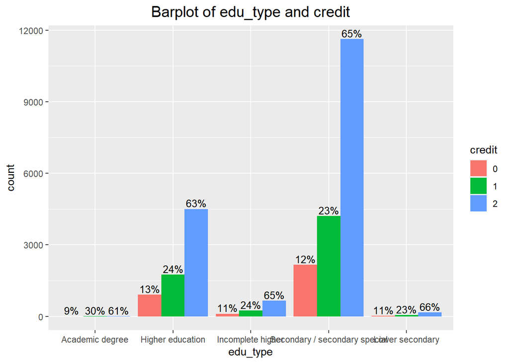

```r
pre_data %>% barplot_factor_variable('edu_type', 'credit', text = FALSE)
```

카이제곱 검정 결과, 교육수준에 따라 신용도의 분포가 다르지 않습니다. 막대그래프에서도 5개의 집단별 비율이 비슷한 것을 확인할 수 있습니다.

```r
pre_data %>% one_variable_chisq_test('house_type', 'credit') # 유의함
```

```
## $table
##                      credit
## house_type                0     1     2
##   Co-op apartment        14    30    66
##   House / apartment    2873  5569 15211
##   Municipal apartment   110   160   548
##   Office apartment       24    48   118
##   Rented apartment       50   147   232
##   With parents          151   313   793
##
## $prop_table
##                      credit
## house_type                    0         1         2
##   Co-op apartment     0.1272727 0.2727273 0.6000000
##   House / apartment   0.1214645 0.2354458 0.6430897
##   Municipal apartment 0.1344743 0.1955990 0.6699267
##   Office apartment    0.1263158 0.2526316 0.6210526
##   Rented apartment    0.1165501 0.3426573 0.5407925
##   With parents        0.1201273 0.2490056 0.6308671
##
## $test
##
##  Pearson's Chi-squared test
##
## data:  .
## X-squared = 37.763, df = 10, p-value = 4.172e-05
```

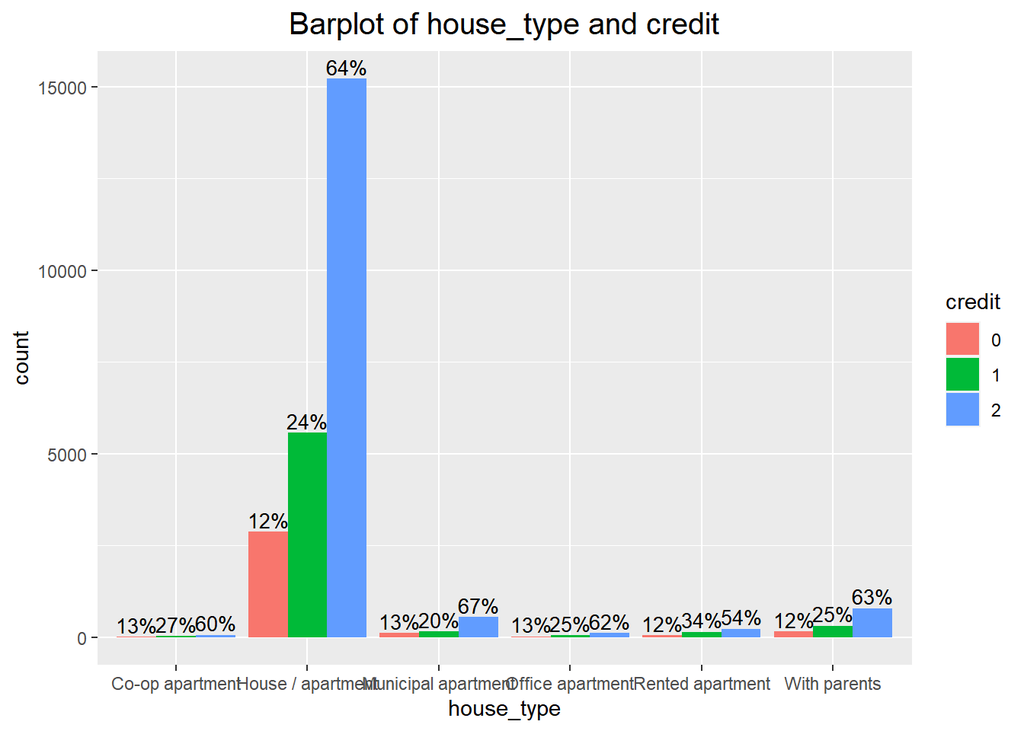

```r
pre_data %>% barplot_factor_variable('house_type', 'credit', text = FALSE)
```

카이제곱 검정 결과, 주거 조건에 따라 신용도의 분포가 다릅니다. 신용도 2의 비율이 가장 낮은 집단은 54%, 가장 높은 집단은 67%인 것을 확인할 수 있습니다.

```r
pre_data %>% one_variable_chisq_test('child_num_category', 'credit') # 유의함
```

```
## $table
##                   credit
## child_num_category     0     1     2
##      zero           2233  4322 11785
##      one             682  1313  3391
##      two             268   535  1559
##      three_or_four    37    91   225
##      five              2     6     2
##      more_than_6       0     0     6
##
## $prop_table
##                   credit
## child_num_category         0         1         2
##      zero          0.1217557 0.2356598 0.6425845
##      one           0.1266246 0.2437802 0.6295952
##      two           0.1134632 0.2265030 0.6600339
##      three_or_four 0.1048159 0.2577904 0.6373938
##      five          0.2000000 0.6000000 0.2000000
##      more_than_6   0.0000000 0.0000000 1.0000000
##
## $test
##
##  Pearson's Chi-squared test
##
## data:  .
## X-squared = 21.097, df = 10, p-value = 0.02043
```

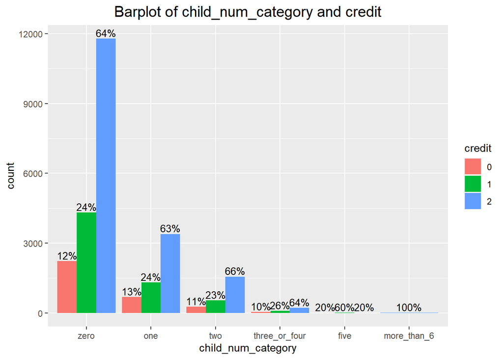

```r
pre_data %>% barplot_factor_variable('child_num_category', 'credit', text = FALSE)
```

카이제곱 검정 결과, 자녀 수에 따라 신용도의 분포가 다릅니다. 0, 1, 2, 3or4의 분포는 비슷하지만 5, 6이상의 분포는 빈도 수도 작을뿐만 아니라 확연히 다른 분포를 확인할 수 있습니다.

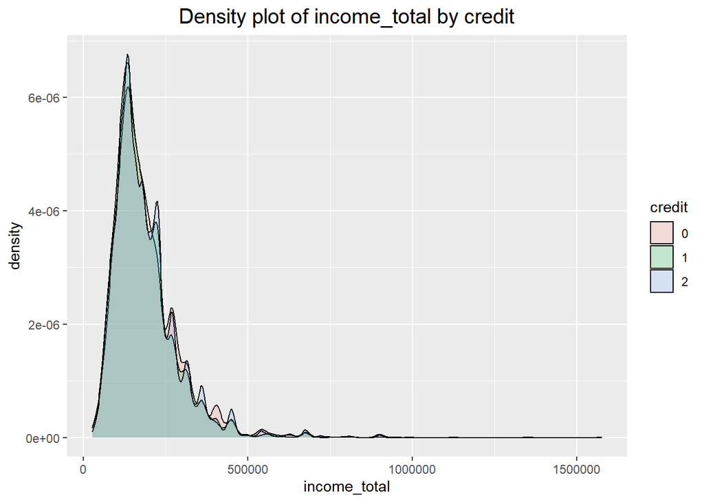

```r
pre_data %>%
    ggplot(aes(x = income_total, fill = credit)) +
    geom_density(alpha = 0.2) +
    ggtitle("Density plot of income_total by credit") +
    theme(plot.title = element_text(size = 15, hjust = 0.5))
```

신용도별 연간 소득 분포를 그려봤을 때 시각적으로 분포의 차이가 느껴지지 않습니다.

```r
pre_data %>%
    group_by(credit) %>%
    summarise(mean = mean(income_total),
              median = median(income_total),
              min = min(income_total),
              max = max(income_total))
```

```
## # A tibble: 3 x 5
##   credit    mean median   min     max
##   <fct>    <dbl>  <dbl> <dbl>   <dbl>
## 1 0      190808. 162000 29250  945000
## 2 1      181123. 157500 27000 1125000
## 3 2      188926. 157500 27000 1575000
```

신용도별 연간 소득의 대표값을 확인해봤을때도 최댓값 말고는 크게 차이나는 대표값이 없습니다.

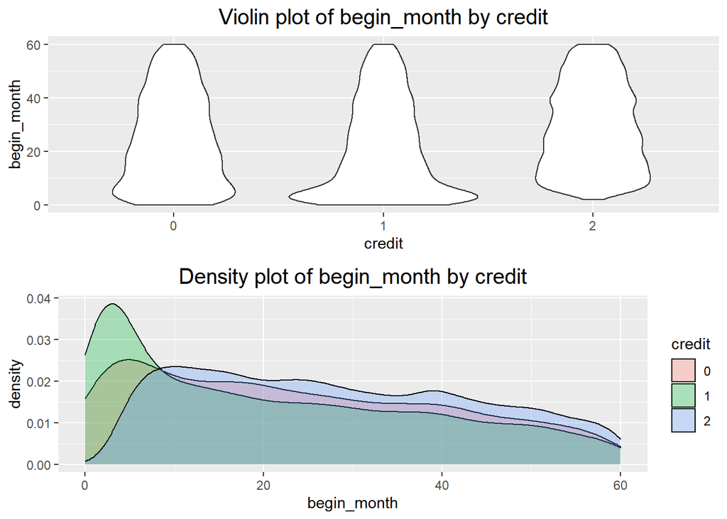

```r
plot_begin_month1 = pre_data %>%
    ggplot(aes(x = credit, y = begin_month)) +
    geom_violin() +
    ggtitle("Violin plot of begin_month by credit") +
    theme(plot.title = element_text(size = 15, hjust = 0.5))

plot_begin_month2 = pre_data %>%
    ggplot(aes(x = begin_month, fill = credit)) +
    geom_density(alpha = 0.3) +
    ggtitle("Density plot of begin_month by credit") +
    theme(plot.title = element_text(size = 15, hjust = 0.5))

grid.arrange(plot_begin_month1, plot_begin_month2, ncol = 1)
```

신용도별 카드 발급 월 수의 분포에 시각적으로 차이가 있음을 확인할 수 있습니다. 신용도 1의 경우, 다른 집단에 비해 아래가 두껍고 위가 얇습니다. 신용도 2의 경우, 다른 집단에 비해 아래가 매우 얇습니다.

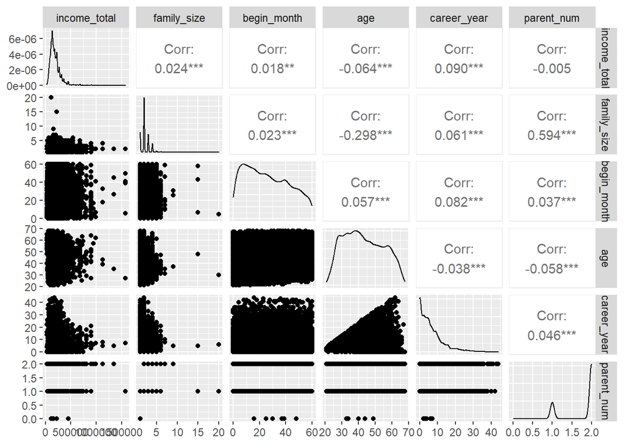

```r
pre_data %>% select(-index) %>% select_if(is.numeric) %>% ggpairs()
```

## EDA 결과 정리

카이제곱 검정을 통해 통계적으로 유의미한 차이가 있다고 하더라도, 그룹의 비율을 확인하면 크게 차이나지 않는 경우도 있다. 단일 변수만 가지고 신용도에 따른 분포 차이를 확인하기 힘들다고 판단해 변수 간 상호작용항을 만들어 모델 학습에 이용하려고 합니다.

# 2. Modeling

## 데이터 준비

```r
pre_data %>%
  select(credit) %>%
  table()
```

```
## .
##     0     1     2
##  3222  6267 16968
```

데이터의 종속변수가 불균형하므로 층화추출법을 이용한 holdout 방법을 사용하도록 하겠습니다.

```r
pre_data = pre_data %>%
    mutate(edu_type = as.factor(edu_type),
           child_num_category = as.factor(child_num_category))

pre_test_data = pre_test_data %>%
    mutate(edu_type = as.factor(edu_type),
           child_num_category = as.factor(child_num_category))

set.seed(20152410)

train_number = createDataPartition(pre_data[['credit']], p = 0.8)
train_data = pre_data %>% dplyr::slice(train_number$Resample1)
validation_data = pre_data %>% dplyr::slice(-train_number$Resample1)
```

```r
resample_data = function(df){

    ### 불균형 데이터에서 빈도수가 적은 종속변수의 샘플을 2배로 오버샘플링
    resampled_0 = df %>%
        filter(credit == 0) %>%
        rbind(df %>% filter(credit == 0))

    resampled_1 = df %>%
        filter(credit == 1) %>%
        rbind(df %>% filter(credit == 1))

    resampled_df = df %>%
        filter(credit == 2) %>%
        rbind(resampled_0) %>%
        rbind(resampled_1) %>%
        arrange(index)

    return(resampled_df)
}

resampled_data = resample_data(train_data)
```

오버샘플링을 통해 불균형 데이터의 문제를 해결할 수 있다고 생각해 리샘플링으로 빈도 수가 작은 집단을 추가하였습니다. 원 데이터와 오버샘플링 데이터 둘 다 모델링을 해보고 성능이 좋은 것을 선택하도록 하겠습니다.

```r
model_formula = formula(credit ~ -1 + income_total + family_size + begin_month + age + career_year + parent_num +
                            (gender + car + reality + income_type + family_type + house_type + work_phone + phone + email + child_num_category)^2)

X_train = model.matrix(model_formula, data = train_data)
X_train_resampled = model.matrix(model_formula, data = resampled_data)
X_val = model.matrix(model_formula, data = validation_data)
X_test = model.matrix(model_formula, data = pre_test_data)

y_train = train_data %>% select(credit) %>% as.matrix() %>%  as.vector()
y_train_resampled = resampled_data %>% select(credit) %>% as.matrix() %>%  as.vector()
y_val = validation_data %>% select(credit) %>% as.matrix() %>%  as.vector()
```

범주형 변수의 2차 상호작용항을 변수로 추가하여 행렬 형태로 바꿔주었습니다. 또한 학습에 바로 사용할 수 있도록 독립변수와 종속변수를 분리하여 저장하였습니다.

## 모델 학습

일반데이터, 리샘플링 데이터를 xgboost, catboost 2개의 모델에 적용해보고 validation 성능이 좋은 데이터와 모델을 선택하도록 하겠습니다.

### xgboost

```r
xgb_train_matrix = xgb.DMatrix(data = X_train, label = y_train)
xgb_train_resampled_matrix = xgb.DMatrix(data = X_train_resampled, label = y_train_resampled)
xgb_val_matrix = xgb.DMatrix(data = X_val, label = y_val)
```

```r
set.seed(20152410)
xgb_model = xgb.train(data = xgb_train_matrix,
                      objective = 'multi:softprob',
                      eval_metric = 'mlogloss',
                      num_class = 3,
                      nrounds = 1000,
                      eta = 0.3,
                      watchlist = list(val = xgb_val_matrix),
                      early_stopping_rounds = 50)
```

```r
set.seed(20152410)
xgb_model_resampled = xgb.train(data = xgb_train_resampled_matrix,
                                objective = 'multi:softprob',
                                eval_metric = 'mlogloss',
                                num_class = 3,
                                nrounds = 1000,
                                eta = 0.3,
                                watchlist = list(val = xgb_val_matrix),
                                early_stopping_rounds = 50)
```

```r
xgb_predict = function(model, newdata){
    ### xgb 모델의 예측 확률, 예측 클래스 생성
    probs = predict(model, newdata = newdata) %>%
        matrix(nrow = model$call$num_class, ncol = dim(newdata)[1]) %>%
        t()

    classes = probs %>%
        apply(1, function(x){which.max(x) - 1}) %>%
        as.factor()

    return(list(prob = probs,
                class = classes))
}

prediction_xgb_model = xgb_predict(xgb_model, xgb_val_matrix)
prediction_xgb_model_resampled = xgb_predict(xgb_model_resampled, xgb_val_matrix)
```

```r
xgb_eval_df = data.frame(model = c("xgboost",
                                   "xgboost_resampled"),
                         accuracy = c(Accuracy(prediction_xgb_model$class, as.factor(y_val)),
                                      Accuracy(prediction_xgb_model_resampled$class, as.factor(y_val))),
                         logloss = c(MultiLogLoss(prediction_xgb_model$prob, as.factor(y_val)),
                                     MultiLogLoss(prediction_xgb_model_resampled$prob, as.factor(y_val)))
                     )

xgb_eval_df
```

```
##               model  accuracy   logloss
## 1           xgboost 0.6981096 0.7577718
## 2 xgboost_resampled 0.6939509 0.7899155
```

xgboost 모델 학습 결과 원 데이터로 학습한 모델의 validation logloss가 리샘플링 데이터로 학습한 모델의 성능보다 좋습니다.

### catboost

xgboost에서 오버샘플링 데이터의 validation 성능이 더 좋지 않았기 때문에 catboost에선 오버샘플링을 하지 않은 데이터만 이용해서 학습해보도록 하겠습니다.

```r
cat_train_matrix = catboost.load_pool(data = X_train,
                                      label = as.integer(y_train),
                                      cat_features = seq(6, 274))

cat_val_matrix = catboost.load_pool(data = X_val,
                                    label = as.integer(y_val),
                                    cat_features = seq(6, 274))

cat_test_matrix = catboost.load_pool(data = X_test,
                                     cat_features = seq(6, 274))
```

```r
cat_model = catboost.train(learn_pool = cat_train_matrix,
                           test_pool = cat_val_matrix,
                           params = list(
                               loss_function = 'MultiClass',
                               eval_metric = 'MultiClass',
                               classes_count = 3,
                               iterations = 500,
                               learning_rate = 0.5,
                               random_seed = 20152410,
                               metric_period = 10))
```

```r
cat_model2 = catboost.train(learn_pool = cat_train_matrix,
                            test_pool = cat_val_matrix,
                            params = list(
                                loss_function = 'MultiClassOneVsAll',
                                eval_metric = 'MultiClassOneVsAll',
                                classes_count = 3,
                                iterations = 500,
                                learning_rate = 0.5,
                                random_seed = 20152410,
                                metric_period = 10))
```

```r
cat_predict = function(model, newdata){
    ### catboost 모델의 예측 확률, 예측 클래스 생성
    probs = catboost.predict(cat_model,
                             pool = cat_val_matrix,
                             prediction_type = 'Probability')

    classes = catboost.predict(cat_model,
                               pool = cat_val_matrix,
                               prediction_type = 'Class') %>%
        as.factor()

    return(list(prob = probs,
                class = classes))
}

prediction_cat_model = cat_predict(cat_model, cat_val_matrix)
prediction_cat_model2 = cat_predict(cat_model, cat_val_matrix)
```

### 모델링 결과 정리

```r
# evaluate model performance
eval_df = data.frame(model = c("xgboost",
                               "xgboost_resampled",
                               'catboost_MultiClass_loss',
                               'catboost_MultiClassOneVsAll_loss'),
                     accuracy = c(Accuracy(prediction_xgb_model$class, as.factor(y_val)),
                                  Accuracy(prediction_xgb_model_resampled$class, as.factor(y_val)),
                                  Accuracy(prediction_cat_model$class, as.factor(y_val)),
                                  Accuracy(prediction_cat_model2$class, as.factor(y_val))),
                     logloss = c(MultiLogLoss(prediction_xgb_model$prob, as.factor(y_val)),
                                 MultiLogLoss(prediction_xgb_model_resampled$prob, as.factor(y_val)),
                                 MultiLogLoss(prediction_cat_model$prob, as.factor(y_val)),
                                 MultiLogLoss(prediction_cat_model2$prob, as.factor(y_val))))

eval_df
```

```
##                              model  accuracy   logloss
## 1                          xgboost 0.6981096 0.7577718
## 2                xgboost_resampled 0.6939509 0.7899155
## 3         catboost_MultiClass_loss 0.6455577 0.8802409
## 4 catboost_MultiClassOneVsAll_loss 0.6455577 0.8802409
```

모델링 결과 validation set에 대해 catboost보다 xgboost의 성능이 더 우수합니다. 따라서 xgboost 모델 두 개를 학습하여 test 데이터에 대한 예측값을 생성한 뒤 결과를 제출해보도록 하겠습니다.

# 3. Predict

## 후보 모델 1번

```r
xgb_model
```

```
## ##### xgb.Booster
## Handle is invalid! Suggest using xgb.Booster.complete
## raw: 2.1 Mb
## call:
##   xgb.train(data = xgb_train_matrix, nrounds = 1000, watchlist = list(val = xgb_val_matrix),
##     early_stopping_rounds = 50, objective = "multi:softprob",
##     eval_metric = "mlogloss", num_class = 3, eta = 0.3)
## params (as set within xgb.train):
##   objective = "multi:softprob", eval_metric = "mlogloss", num_class = "3", eta = "0.3", validate_parameters = "TRUE"
## callbacks:
##   cb.print.evaluation(period = print_every_n)
##   cb.evaluation.log()
##   cb.early.stop(stopping_rounds = early_stopping_rounds, maximize = maximize,
##     verbose = verbose)
## # of features: 275
## niter: 159
## best_iteration : 109
## best_ntreelimit : 109
## best_score : 0.757772
## best_msg : [109] val-mlogloss:0.757772
## nfeatures : 275
## evaluation_log:
##     iter val_mlogloss
##        1     0.978131
##        2     0.908538
## ---
##      158     0.759707
##      159     0.759692
```

학습 결과 학습률 = 0.3 조건 하에서 109개의 tree를 생성하였습니다.

전체 데이터로 학습 후 예측값 생성하도록 하겠습니다.

```r
pre_data_matrix = model.matrix(model_formula, data = pre_data)
pre_data_label = pre_data %>% select(credit) %>% as.matrix() %>%  as.vector()

pre_data_xgb_matrix = xgb.DMatrix(data = pre_data_matrix, label = pre_data_label)

set.seed(20152410)
final_xgb_model = xgboost(data = pre_data_xgb_matrix,
                          objective = 'multi:softprob',
                          eval_metric = 'mlogloss',
                          num_class = xgb_model$params$num_class,
                          nrounds = xgb_model$best_iteration,
                          eta = xgb_model$params$eta)
```

```r
final_xgb_model
```

```
## ##### xgb.Booster
## Handle is invalid! Suggest using xgb.Booster.complete
## raw: 1.5 Mb
## call:
##   xgb.train(params = params, data = dtrain, nrounds = nrounds,
##     watchlist = watchlist, verbose = verbose, print_every_n = print_every_n,
##     early_stopping_rounds = early_stopping_rounds, maximize = maximize,
##     save_period = save_period, save_name = save_name, xgb_model = xgb_model,
##     callbacks = callbacks, objective = "multi:softprob", eval_metric = "mlogloss",
##     num_class = ..3, eta = ..4)
## params (as set within xgb.train):
##   objective = "multi:softprob", eval_metric = "mlogloss", num_class = "3", eta = "0.3", validate_parameters = "TRUE"
## callbacks:
##   cb.print.evaluation(period = print_every_n)
##   cb.evaluation.log()
## # of features: 275
## niter: 109
## nfeatures : 275
## evaluation_log:
##     iter train_mlogloss
##        1       0.974959
##        2       0.903493
## ---
##      108       0.603380
##      109       0.601501
```

```r
pred_test = predict(final_xgb_model, newdata = X_test) %>%
    matrix(nrow = final_xgb_model$params$num_class, ncol = dim(X_test)[1]) %>%
    t() %>%
    as.data.frame() %>%
    dplyr::rename('0' = V1, '1' = V2, '2' = V3)

submission = pre_test_data %>%
    select(index) %>%
    cbind(pred_test)
```

```r
submission %>% head()
```

```
##   index          0         1         2
## 1 26457 0.08870175 0.1539241 0.7573742
## 2 26458 0.20148724 0.1281913 0.6703214
## 3 26459 0.09049558 0.1493337 0.7601708
## 4 26460 0.20190334 0.1287423 0.6693543
## 5 26461 0.06616089 0.1259030 0.8079361
## 6 26462 0.07162800 0.1799086 0.7484634
```

```r
submission %>%
    select(-index) %>%
    apply(1, function(x){which.max(x) - 1}) %>%
    table()
```

```
## .
##    0    1    2
##  180  952 8868
```

생성된 예측값은 위와 같습니다. 예측 결과를 제출하여 test 데이터에 대한 성능 평과 결과 test logloss : 0.7611119983를 기록하였습니다.

## 후보 모델 2번

```r
xgb_model_resampled
```

```
## ##### xgb.Booster
## Handle is invalid! Suggest using xgb.Booster.complete
## raw: 2.7 Mb
## call:
##   xgb.train(data = xgb_train_resampled_matrix, nrounds = 1000,
##     watchlist = list(val = xgb_val_matrix), early_stopping_rounds = 50,
##     objective = "multi:softprob", eval_metric = "mlogloss", num_class = 3,
##     eta = 0.3)
## params (as set within xgb.train):
##   objective = "multi:softprob", eval_metric = "mlogloss", num_class = "3", eta = "0.3", validate_parameters = "TRUE"
## callbacks:
##   cb.print.evaluation(period = print_every_n)
##   cb.evaluation.log()
##   cb.early.stop(stopping_rounds = early_stopping_rounds, maximize = maximize,
##     verbose = verbose)
## # of features: 275
## niter: 191
## best_iteration : 141
## best_ntreelimit : 141
## best_score : 0.789916
## best_msg : [141] val-mlogloss:0.789916
## nfeatures : 275
## evaluation_log:
##     iter val_mlogloss
##        1     1.019547
##        2     0.969305
## ---
##      190     0.790917
##      191     0.790588
```

학습 결과 학습률 = 0.3 조건 하에서 141개의 tree를 생성하였습니다.

전체 데이터로 학습 후 예측값 생성하도록 하겠습니다.

```r
pre_data_resampled = resample_data(pre_data)

pre_data_resampled_matrix = model.matrix(model_formula, data = pre_data_resampled)
pre_data_resampled_label = pre_data_resampled %>% select(credit) %>% as.matrix() %>%  as.vector()

pre_data_xgb_matrix = xgb.DMatrix(data = pre_data_resampled_matrix, label = pre_data_resampled_label)

set.seed(20152410)
final_xgb_model_resampled = xgboost(data = pre_data_xgb_matrix,
                                    objective = 'multi:softprob',
                                    eval_metric = 'mlogloss',
                                    num_class = xgb_model_resampled$params$num_class,
                                    nrounds = xgb_model_resampled$best_iteration,
                                    eta = xgb_model_resampled$params$eta)
```

```r
final_xgb_model_resampled
```

```
## ##### xgb.Booster
## Handle is invalid! Suggest using xgb.Booster.complete
## raw: 2 Mb
## call:
##   xgb.train(params = params, data = dtrain, nrounds = nrounds,
##     watchlist = watchlist, verbose = verbose, print_every_n = print_every_n,
##     early_stopping_rounds = early_stopping_rounds, maximize = maximize,
##     save_period = save_period, save_name = save_name, xgb_model = xgb_model,
##     callbacks = callbacks, objective = "multi:softprob", eval_metric = "mlogloss",
##     num_class = ..3, eta = ..4)
## params (as set within xgb.train):
##   objective = "multi:softprob", eval_metric = "mlogloss", num_class = "3", eta = "0.3", validate_parameters = "TRUE"
## callbacks:
##   cb.print.evaluation(period = print_every_n)
##   cb.evaluation.log()
## # of features: 275
## niter: 141
## nfeatures : 275
## evaluation_log:
##     iter train_mlogloss
##        1       1.039051
##        2       1.001842
## ---
##      140       0.655210
##      141       0.653632
```

```r
pred_test_resampled = predict(final_xgb_model_resampled, newdata = X_test) %>%
    matrix(nrow = final_xgb_model_resampled$params$num_class, ncol = dim(X_test)[1]) %>%
    t() %>%
    as.data.frame() %>%
    dplyr::rename('0' = V1, '1' = V2, '2' = V3)

submission_resampled = pre_test_data %>%
    select(index) %>%
    cbind(pred_test_resampled)
```

```r
submission_resampled %>% head()
```

```
##   index          0         1         2
## 1 26457 0.09858839 0.2937237 0.6076880
## 2 26458 0.27629355 0.1776550 0.5460514
## 3 26459 0.07888986 0.1859965 0.7351137
## 4 26460 0.23585811 0.2105023 0.5536396
## 5 26461 0.07214834 0.2132806 0.7145711
## 6 26462 0.07265696 0.2213632 0.7059799
```

```r
submission_resampled %>%
    select(-index) %>%
    apply(1, function(x){which.max(x) - 1}) %>%
    table()
```

```
## .
##    0    1    2
##  486 1734 7780
```

생성된 예측값은 위와 같습니다. 예측 결과를 제출하여 test 데이터에 대한 성능 평과 결과 test logloss : 0.7960758665를 기록하였습니다.

리샘플링의 비율 조정하고 xgboost 모델의 초모수를 조정하여 성능을 더 높힐 수 있을 것으로 기대하고, 대회가 끝나기 전까지 지속적으로 제출해보려고 합니다.